# Worksheet: Logistic Regression

ISLR, Chapter 4.3

Author

Josh Campbell · Graham Sayle · Kyle Dong · Gerry Peng

Run each block, then change the lines marked `TO DO` or `CHANGE ME` and run it again.

```r
# Use data/Default.csv if it's there; otherwise fall back to the ISLR2 package
if (file.exists("data/Default.csv")) {
  Default <- read.csv("data/Default.csv", stringsAsFactors = TRUE)
} else {
  Default <- ISLR2::Default
}
str(Default)
```

```
'data.frame':   10000 obs. of  4 variables:
 $ default: Factor w/ 2 levels "No","Yes": 1 1 1 1 1 1 1 1 1 1 ...
 $ student: Factor w/ 2 levels "No","Yes": 1 2 1 1 1 2 1 2 1 1 ...
 $ balance: num  730 817 1074 529 786 ...
 $ income : num  44362 12106 31767 35704 38463 ...
```

## 1. Simple Logistic Regression

Fit a logistic regression model predicting `default` using credit card `balance`.

```r
fit_balance <- glm(default ~ balance, data = Default, family = binomial)
```

The fitted model has the form:

$$\Pr(\text{default} = \text{Yes} \mid \text{balance}) = \frac{e^{\beta_0 + \beta_1 \, \text{balance}}}{1 + e^{\beta_0 + \beta_1 \, \text{balance}}}$$

**Solve:**

1. The estimated intercept ($\beta_0$) and balance ($\beta_1$) coefficient.
2. Is the balance coefficient ($\beta_1$) positive or negative? What does that signify?
3. What are the logits if we are looking at someone with a $1000 balance?
4. What are the odds?

```r
coef(fit_balance)
```

```
  (Intercept)       balance
-10.651330614   0.005498917
```

```r
log_odds <- sum(coef(fit_balance) * c(1, 1000))
log_odds
```

```
[1] -5.152414
```

```r
odds <- exp(log_odds)
odds
```

```
[1] 0.005785424
```

## 2. Likelihood by hand

> **Point:** maximum likelihood picks the $\beta$’s that make the observed data most probable.

```r
x <- c(500, 1000, 1400, 1700, 2000, 2400)   # balances
y <- c(0,   0,    0,    1,    0,    1)      # 1 = defaulted

beta0 <- -6; beta1 <- 0.003                 # <- CHANGE ME: try to beat the MLE

p <- exp(beta0 + beta1 * x) / (1 + exp(beta0 + beta1 * x))
prod(ifelse(y == 1, p, 1 - p))              # your likelihood
```

```
[1] 0.08979767
```

```r
fit_toy <- glm(y ~ x, family = binomial)
coef(fit_toy)                               # the MLE
```

```
 (Intercept)            x
-6.702659405  0.003553105
```

```r
exp(logLik(fit_toy))                        # the largest possible likelihood
```

```
'log Lik.' 0.09484433 (df=2)
```

**Discuss:** Can you beat the MLE’s likelihood? Why not?

## 3. Fitting and predicting on `Default`

> **Point:** prediction is just plugging into the fitted logistic curve.

```r
summary(fit_balance)$coefficients           # Table 4.1
```

```
                 Estimate   Std. Error   z value      Pr(>|z|)
(Intercept) -10.651330614 0.3611573721 -29.49221 3.623124e-191
balance       0.005498917 0.0002203702  24.95309 1.976602e-137
```

```r
predict(fit_balance, newdata = data.frame(balance = c(1000, 2000)),   # <- CHANGE ME
        type = "response")
```

```
          1           2
0.005752145 0.585769370
```

```r
fit_stu <- glm(default ~ student, data = Default, family = binomial)
summary(fit_stu)$coefficients               # Table 4.2
```

```
              Estimate Std. Error    z value     Pr(>|z|)
(Intercept) -3.5041278 0.07071301 -49.554219 0.0000000000
studentYes   0.4048871 0.11501883   3.520181 0.0004312529
```

```r
predict(fit_stu, newdata = data.frame(student = c("Yes", "No")),
        type = "response")
```

```
         1          2
0.04313859 0.02919501
```

**Discuss:**

1. At what balance is the predicted probability of default 0.5? Find it by changing the balances above.
2. What does the `student` coefficient tell you about students vs. non-students?

## 4. Multiple Logistic Regression

**Simulate data**

```r
set.seed(42)        # TO DO (optional): change the seed
n <- 1000

sim_data <- data.frame(
  x1 = rnorm(n),
  x2 = rnorm(n),
  x3 = rnorm(n)
)

# x1 and x2 affect the outcome; x3 has no true effect
true_probability <- with(sim_data, plogis(-0.5 + 1.5 * x1 - x2))

sim_data$y <- rbinom(n, size = 1, prob = true_probability)

train_rows <- sample(seq_len(n), size = 700)
train <- sim_data[train_rows, ]
test <- sim_data[-train_rows, ]

head(train)
```

```
            x1           x2         x3 y
320  1.0458738 -0.553224406  0.1341477 1
77   0.7681787 -0.156872383 -1.0321010 0
158 -0.8002822  0.253718401 -0.4710937 0
232  0.9479520  0.007670604 -0.9283370 1
96  -0.8607926  0.373134505 -1.8646611 0
342  0.6704981  0.737494637 -0.4354801 1
```

**Choose predictors: TO DO!**

```r
# TO DO: select any combination of "x1", "x2", and "x3"
predictors <- c("x1", "x2", "x3")

model_formula <- reformulate(predictors, response = "y")
print(model_formula)
```

```
y ~ x1 + x2 + x3
```

```r
model <- glm(model_formula, data = train, family = binomial())

summary(model)
```

```
Call:
glm(formula = model_formula, family = binomial(), data = train)

Coefficients:
            Estimate Std. Error z value Pr(>|z|)
(Intercept) -0.62264    0.09959  -6.252 4.05e-10 ***
x1           1.49094    0.12751  11.693  < 2e-16 ***
x2          -0.97946    0.11124  -8.805  < 2e-16 ***
x3          -0.01920    0.09445  -0.203    0.839
---
Signif. codes:  0 '***' 0.001 '**' 0.01 '*' 0.05 '.' 0.1 ' ' 1

(Dispersion parameter for binomial family taken to be 1)

    Null deviance: 937.14  on 699  degrees of freedom
Residual deviance: 658.43  on 696  degrees of freedom
AIC: 666.43

Number of Fisher Scoring iterations: 5
```

*Discussion:* What is the interpretation of the intercept? Can we make it meaningful? (Hint: think about standardizing variables.) Do your coefficients change based on what other predictors are added?

**Predict and evaluate classifications: TO DO!**

```r
# TO DO: try thresholds such as 0.3, 0.5, and 0.7
threshold <- 0.37
probabilities <- predict(model, newdata = test, type = "response")
predictions <- as.integer(probabilities >= threshold)

table(
  Actual = factor(test$y, levels = 0:1),
  Predicted = factor(predictions, levels = 0:1)
)
```

```
      Predicted
Actual   0   1
     0 115  46
     1  27 112
```

```r
c(accuracy = mean(predictions == test$y))
```

```
 accuracy
0.7566667
```

*Discussion:* Given the table, how would you calculate accuracy?

**Plot fitted probability curve: TO DO!**

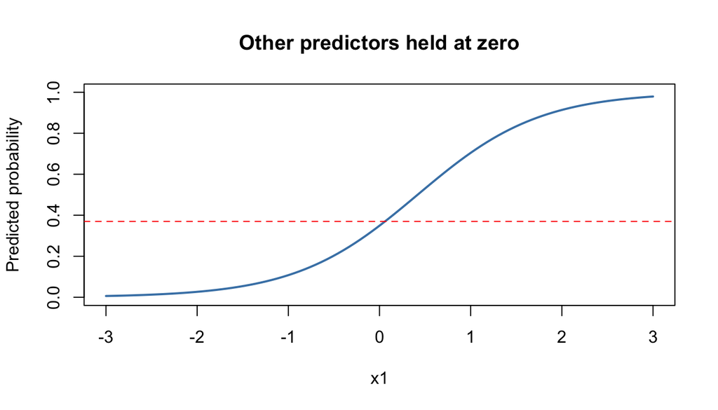

```r
# TO DO: choose a predictor included in your fitted model
plot_predictor <- predictors[1]       # Or "x1", "x2", or "x3"

stopifnot(plot_predictor %in% predictors)

grid <- data.frame(
  x1 = rep(0, 100),
  x2 = rep(0, 100),
  x3 = rep(0, 100)
)
grid[[plot_predictor]] <- seq(-3, 3, length.out = 100)

plot(
  grid[[plot_predictor]],
  predict(model, newdata = grid, type = "response"),
  type = "l", lwd = 2, col = "steelblue",
  ylim = c(0, 1),
  xlab = plot_predictor,
  ylab = "Predicted probability",
  main = "Other predictors held at zero"
)

abline(h = threshold, lty = 2, col = "red")
```

## 5. Multinomial Logistic Regression

Softmax converts scores for different classes into probabilities that add up to 1.

```r
# Scores for three possible diagnoses: stroke, drug overdose, epileptic seizure
scores <- c(2, 1, 0)                        # TO DO: change the scores

# Calculate probabilities using softmax
probabilities <- exp(scores) / sum(exp(scores))

round(probabilities, 3)
```

```
[1] 0.665 0.245 0.090
```

```r
sum(probabilities)
```

```
[1] 1
```

**TO DO:** Change the scores and rerun the code. Try `c(1, 2, 0)`.

**Discussion:**

1. Which diagnosis now has the highest probability?
2. Do the probabilities still add up to 1?
3. What happens if all three scores are equal?